# STS 112: Lab 6

James Chapman

In this lab, we will make more population pyramids to explore the effects of immigration legislation on immigration to the United States from a variety of countries.

## Getting started

Load `tidyverse` and read in the data for Week 6. Remove records for Alaska and Hawaii.

```r
library(tidyverse)
```

```r
ipums = read_csv("wk6_small.csv") %>% filter(YEAR > 1950 | !STATEFIP %in% c(2,15))
```

```r
ipums %>% filter(YEAR < 1960 & STATEFIP %in% c(2,15))
```

| YEAR | STATEFIP | PERWT | SEX | AGE | BPL | BPLD |
| --- | --- | --- | --- | --- | --- | --- |

## Classifying birthplaces

In this lab, we will only be making pyramids for individuals born outside the United States, but we want to graph their numbers as a proportion of the total population. For that reason, we will keep individuals born in the United States in the data frame until the end. Create a new variable called `BPLACE` that classifies `BPL` and/or `BPLD` into the following categories: United States, Western Hemisphere, Northern and Western Europe, Southern and Eastern Europe, Asia, Other.

```r
#Note: US OUTLYING AREA/TERRITORIES are being included in the United States Category.

birthplace = ipums %>% mutate(BPLACE = ifelse(BPL <= 120, 1,
                                       ifelse(BPL <= 300, 2,
                                       ifelse(BPL <= 440, 3,
                                       ifelse(BPL <= 499, 4,
                                       ifelse(BPL <= 599, 5, 6)))))) %>%
             mutate(BPLACE = factor(BPLACE, labels = c("United States", "W. Hemisphere", "N. & W. Europe", "S. & E. Europe", "Asia", "Other")))

table(birthplace$BPL, birthplace$BPLACE)
```

```
      United States W. Hemisphere N. & W. Europe S. & E. Europe   Asia  Other
  1          169185             0              0              0      0      0
  2            3800             0              0              0      0      0
  4           26114             0              0              0      0      0
  5          108566             0              0              0      0      0
  6          253672             0              0              0      0      0
  8           49041             0              0              0      0      0
  9           73428             0              0              0      0      0
  10          14197             0              0              0      0      0
  11          22781             0              0              0      0      0
  12          86514             0              0              0      0      0
  13         196268             0              0              0      0      0
  15          13754             0              0              0      0      0
  16          22014             0              0              0      0      0
  17         371104             0              0              0      0      0
```

[output cut: 143 more lines]

## Making population pyramids

Now add age groups and factor `SEX`.

```r
agegrp <- "0-9"
for (n in (1:7)) {
  agegrp <- c(agegrp, paste(n, "0-", n, "9", sep = ""))
}
agegrp <- c(agegrp, "80+")

birthplace = birthplace %>% mutate(SEXF = factor(SEX, labels = c("Male", "Female"))) %>%
                            mutate(AGEG = factor(ifelse(AGE >= 80, 8, AGE %/% 10), labels = agegrp))
```

Create column `n`, representing the number of people in each unique combination of `YEAR`, `BPLACE`, `SEXF`, and `AGEG` (the numerator), and create column `TOTAL`, representing the total number of people in each year (the denominator).

```r
birthplace = birthplace %>% group_by(YEAR) %>%
                     count(BPLACE, SEXF, AGEG, wt = PERWT) %>%
                     mutate(TOTAL = sum(n))
```

Change `n` values for men to negative values and remove rows for individuals born in the United States.

```r
birthplace <- birthplace %>% filter(BPLACE != "United States") %>% mutate(n = ifelse(SEXF == "Male", 0-n, n))
```

Now plot the population pyramids, faceting on `BPLACE` and animating by `YEAR`. You will need to adjust the breaks and labels on the y-axis to make the pyramids legible. **Pay attention to legibility of the breaks and labels on the y-axis.**

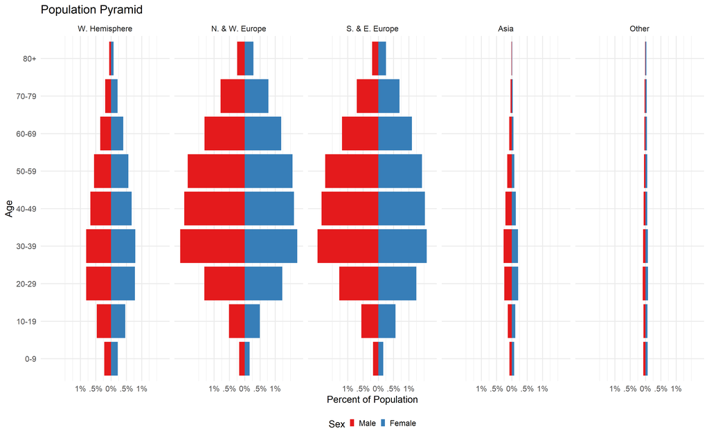

```r
pyramid = ggplot(birthplace, aes(AGEG, n/TOTAL, fill = SEXF)) + geom_col() + coord_flip() + scale_fill_brewer(palette = "Set1") +
  scale_y_continuous(breaks = seq(-.01, .01, .005),
                     labels = c("1%", ".5%","0%", ".5%","1%")) +
  theme_minimal(base_size = 40) + theme(legend.position = "bottom") +
  labs(x = "Age", y = "Percent of Population", fill = "Sex", title = "Population Pyramid") +
  facet_grid(cols = vars(BPLACE))
pyramid
```

```r
library(gganimate)
library(gifski)

options(gganimate.dev_args = list(width = 1800, height = 860))
pyramid + transition_manual(YEAR) + labs(title = "Population Pyramid, {current_frame}")
```

```r
anim_save("pyramid1.gif")
```

Include a reference to the `.gif` file here:

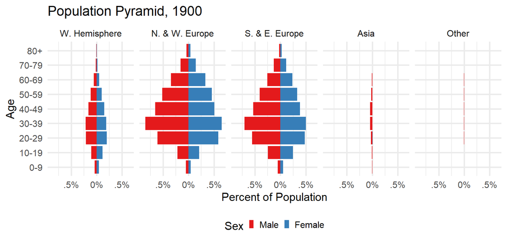

Save and preview your lab and submit it on Canvas